# Data Science Job Market Analysis

Salary Trends Across Experience Level, Work Setting, and Job Category

Mahdi Taheri

2026-10-03

# Executive Summary

> This analysis of **5,004 cleaned data-science job records** (sourced from the “Jobs and Salaries in Data Science” dataset on Kaggle) examined how experience level, work arrangement, and job category relate to salary. Experience level, job category, and work setting were all statistically significant predictors of salary. **Machine Learning and AI roles command the highest premium** among job categories (+$48,227 relative to baseline), and — contrary to common assumption — **fully remote roles did not pay more than in-person roles**; hybrid arrangements were actually associated with the lowest average salaries. The final model explains **26.2%** of salary variance (Adjusted R²), indicating that while these factors matter, individual-level attributes not captured in this dataset (specific job title, years of experience, skill set) likely explain a substantial share of the remainder.

# 1. Data Cleaning (performed in SQL)

Data cleaning for this project was carried out in MySQL prior to import into R. The full SQL script is available in `Self_Project.sql` in this repository. Summary of steps:

| Step | Result |
| --- | --- |
| Raw records | 9,355 |
| Duplicate records removed (via `ROW_NUMBER() OVER(PARTITION BY ...)`) | 4,351 |
| Final clean records | 5,004 |
| NULL values in key columns | 0 |
| Inconsistent categorical text values | 0 |
| Invalid (≤ 0) salary values | 0 |

```r
df <- read.csv(choose.files())
str(df)
```

```
## 'data.frame':    5004 obs. of  12 variables:
##  $ work_year         : int  2023 2023 2023 2023 2023 2023 2023 2023 2023 2023 ...
##  $ job_title         : chr  "AI Architect" "AI Architect" "AI Architect" "AI Architect" ...
##  $ job_category      : chr  "Machine Learning and AI" "Machine Learning and AI" "Machine Learning and AI" "Machine Learning and AI" ...
##  $ salary_currency   : chr  "EUR" "USD" "USD" "USD" ...
##  $ salary            : int  200000 146900 200000 204000 305100 330000 50000 60000 150000 200000 ...
##  $ salary_in_usd     : int  215936 146900 200000 204000 305100 330000 53984 64781 161952 215936 ...
##  $ employee_residence: chr  "Belgium" "United States" "United States" "United States" ...
##  $ experience_level  : chr  "Executive" "Senior" "Senior" "Senior" ...
##  $ employment_type   : chr  "Full-time" "Full-time" "Full-time" "Full-time" ...
##  $ work_setting      : chr  "Remote" "Remote" "Remote" "In-person" ...
##  $ company_location  : chr  "United States" "United States" "United States" "United States" ...
##  $ company_size      : chr  "L" "M" "L" "M" ...
```

# 2. Exploratory Data Analysis

## 2.1 Overall Salary Distribution

```r
summary(df$salary_in_usd)
```

```
##    Min. 1st Qu.  Median    Mean 3rd Qu.    Max.
##   15000   96110  140000  146294  187298  450000
```

The median ($140,000) is below the mean ($146,294), indicating a right-skewed distribution driven by a smaller number of very high salaries.

## 2.2 Salary by Experience Level

```r
df %>%
  group_by(experience_level) %>%
  summarise(avg_salary = mean(salary_in_usd), n = n()) %>%
  arrange(desc(avg_salary))
```

```
## # A tibble: 4 × 3
##   experience_level avg_salary     n
##   <chr>                 <dbl> <int>
## 1 Executive           186695.   217
## 2 Senior              162488.  3196
## 3 Mid-level           115840.  1205
## 4 Entry-level          84567.   386
```

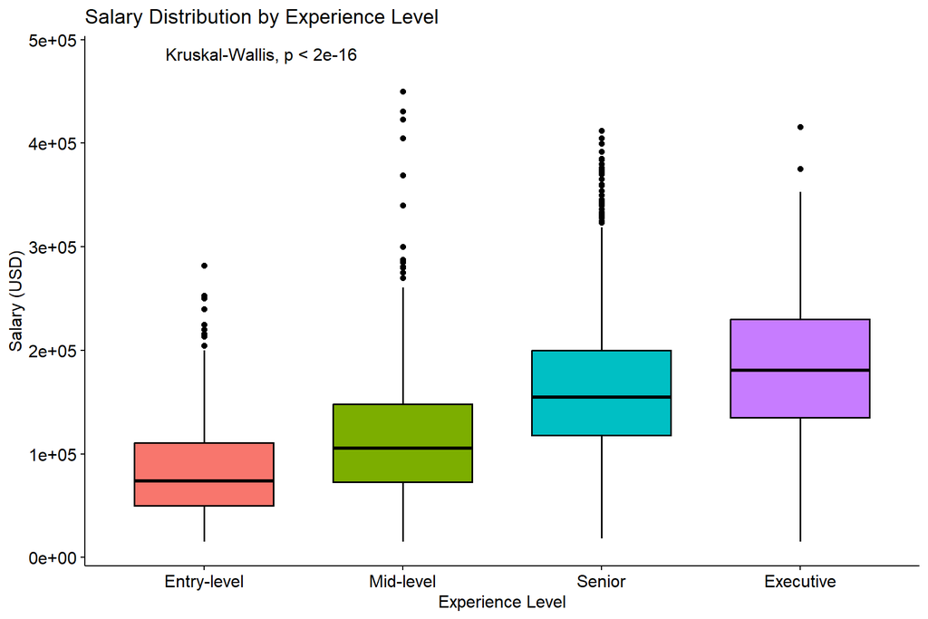

```r
ggboxplot(df, x = "experience_level", y = "salary_in_usd",
          fill = "experience_level",
          order = c("Entry-level", "Mid-level", "Senior", "Executive")) +
  stat_compare_means(method = "kruskal.test", label.y = 480000) +
  labs(title = "Salary Distribution by Experience Level",
       y = "Salary (USD)", x = "Experience Level") +
  theme(legend.position = "none")
```

**Why a boxplot?** A boxplot was used because it simultaneously displays the median, interquartile range, and outliers for each group, making it well-suited for comparing both central tendency and variability across multiple categories at once.

**Observation on outliers:** Several high-salary outliers in the Mid-level group (e.g., Research Scientist, $450,000) were inspected individually and found to be legitimate, high-paying roles at large companies in high-cost-of-living countries — not data errors. This indicates that `experience_level` alone does not fully capture compensation; job role and company characteristics matter independently.

# 3. Checking Assumptions Before Hypothesis Testing

Prior to hypothesis testing, the underlying assumptions of ANOVA — normality and homogeneity of variance — were explicitly checked rather than assumed, since violating them (particularly homogeneity of variance) can inflate the Type I error rate and lead to misleading p-values.

## 3.1 Normality Check

```r
anova_model <- aov(salary_in_usd ~ experience_level, data = df)
```

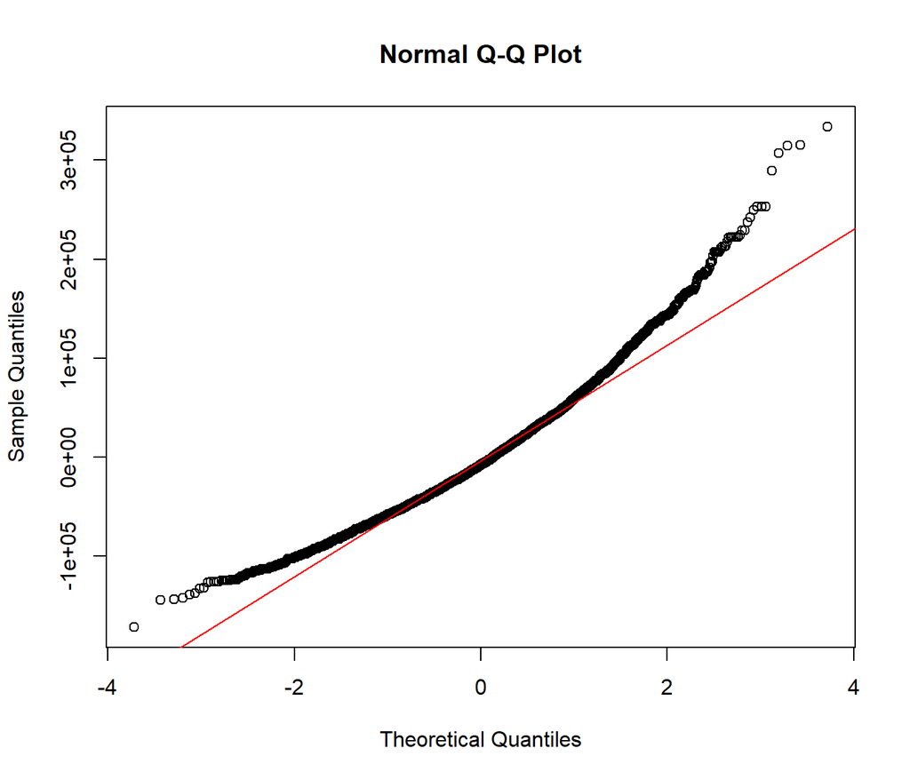

```r
qqnorm(residuals(anova_model))
qqline(residuals(anova_model), col = "red")
```

## 3.2 Homogeneity of Variance Check

```r
leveneTest(salary_in_usd ~ experience_level, data = df)
```

```
## Levene's Test for Homogeneity of Variance (center = median)
##         Df F value    Pr(>F)
## group    3  16.258 1.632e-10 ***
##       5000
## ---
## Signif. codes:  0 '***' 0.001 '**' 0.01 '*' 0.05 '.' 0.1 ' ' 1
```

**Interpretation:** Levene’s Test was used — rather than relying on visual inspection alone — because it provides a formal, objective test of whether group variances are statistically equal, a required assumption for classical ANOVA. The result (F(3, 5000) = 16.26, p < 0.001) indicated that variances were significantly unequal across experience-level groups. Unlike normality, this violation is not resolved by large sample size alone, especially when combined with unequal group sizes (Executive: n = 217 vs. Senior: n = 3,196). This motivated the use of Welch’s ANOVA and Kruskal-Wallis instead of classical ANOVA.

# 4. Hypothesis Testing: Does Experience Level Affect Salary?

## 4.1 Welch’s ANOVA (does not assume equal variances)

```r
welch_result <- oneway.test(salary_in_usd ~ experience_level, data = df, var.equal = FALSE)
welch_result
```

```
##
##  One-way analysis of means (not assuming equal variances)
##
## data:  salary_in_usd and experience_level
## F = 393.04, num df = 3.00, denom df = 729.73, p-value < 2.2e-16
```

> Because the equal-variance assumption was violated, Welch’s one-way ANOVA was used instead of classical ANOVA. The result (F(3, 729.73) = 393.04, p < 0.001) showed a statistically significant difference in mean salary across experience levels.

## 4.2 Kruskal-Wallis Test (non-parametric confirmation)

```r
kruskal.test(salary_in_usd ~ experience_level, data = df)
```

```
##
##  Kruskal-Wallis rank sum test
##
## data:  salary_in_usd by experience_level
## Kruskal-Wallis chi-squared = 937.87, df = 3, p-value < 2.2e-16
```

> As a non-parametric confirmation independent of distributional assumptions, the Kruskal-Wallis test was also performed. The result (χ²(3) = 937.87, p < 0.001) corroborated the Welch ANOVA finding, confirming that salary distributions differ significantly across experience levels.

# 5. Multiple Linear Regression

## 5.1 Model 1: Experience, Work Setting, Company Size

```r
model <- lm(salary_in_usd ~ experience_level + work_setting + company_size, data = df)
summary(model)
```

```
##
## Call:
## lm(formula = salary_in_usd ~ experience_level + work_setting +
##     company_size, data = df)
##
## Residuals:
##     Min      1Q  Median      3Q     Max
## -179114  -43367   -8084   35886  335715
##
## Coefficients:
##                           Estimate Std. Error t value Pr(>|t|)
## (Intercept)                  62695       5152  12.168  < 2e-16 ***
## experience_levelExecutive    94748       5248  18.054  < 2e-16 ***
## experience_levelMid-level    24590       3635   6.764 1.50e-11 ***
## experience_levelSenior       69010       3420  20.177  < 2e-16 ***
## work_settingIn-person        32848       5036   6.523 7.57e-11 ***
## work_settingRemote           21559       4984   4.326 1.55e-05 ***
## company_sizeM                 3822       3144   1.216    0.224
## company_sizeS               -25300       5607  -4.512 6.57e-06 ***
## ---
## Signif. codes:  0 '***' 0.001 '**' 0.01 '*' 0.05 '.' 0.1 ' ' 1
##
## Residual standard error: 61050 on 4996 degrees of freedom
## Multiple R-squared:  0.1867, Adjusted R-squared:  0.1855
## F-statistic: 163.8 on 7 and 4996 DF,  p-value: < 2.2e-16
```

> A multiple linear regression model was fitted with salary_in_usd as the outcome and experience_level, work_setting, and company_size as predictors. The model was statistically significant (F(7, 4996) = 163.8, p < 0.001), explaining 18.6% of the variance in salary (Adjusted R² = 0.1855).

**Notable finding:** Relative to Hybrid (the reference level), both In-person (+$32,848) and Remote (+$21,559) roles pay more — hybrid arrangements show the lowest average salary among the three.

## 5.2 Model 2: Adding Job Category

```r
model2 <- lm(salary_in_usd ~ experience_level + work_setting + company_size + job_category, data = df)
summary(model2)
```

```
##
## Call:
## lm(formula = salary_in_usd ~ experience_level + work_setting +
##     company_size + job_category, data = df)
##
## Residuals:
##     Min      1Q  Median      3Q     Max
## -173608  -40169   -6173   32935  336978
##
## Coefficients:
##                                            Estimate Std. Error t value Pr(>|t|)
## (Intercept)                                   38991       6558   5.946 2.93e-09
## experience_levelExecutive                     90781       5067  17.916  < 2e-16
## experience_levelMid-level                     21763       3478   6.258 4.22e-10
## experience_levelSenior                        62632       3290  19.038  < 2e-16
## work_settingIn-person                         35859       4798   7.474 9.14e-14
## work_settingRemote                            26280       4752   5.531 3.35e-08
## company_sizeM                                  6806       2999   2.269  0.02329
## company_sizeS                                -31360       5358  -5.853 5.13e-09
## job_categoryCloud and Database                21653      26360   0.821  0.41145
## job_categoryData Analysis                     -9430       4773  -1.976  0.04824
## job_categoryData Architecture and Modeling    24760       6352   3.898 9.82e-05
## job_categoryData Engineering                  16127       4623   3.488  0.00049
## job_categoryData Management and Strategy      -6831       9421  -0.725  0.46842
## job_categoryData Quality and Operations      -22091       9652  -2.289  0.02214
## job_categoryData Science and Research         33644       4505   7.468 9.59e-14
## job_categoryLeadership and Management         16833       5324   3.162  0.00158
## job_categoryMachine Learning and AI           48227       4687  10.289  < 2e-16
##
## (Intercept)                                ***
## experience_levelExecutive                  ***
## experience_levelMid-level                  ***
## experience_levelSenior                     ***
## work_settingIn-person                      ***
## work_settingRemote                         ***
## company_sizeM                              *
## company_sizeS                              ***
## job_categoryCloud and Database
## job_categoryData Analysis                  *
## job_categoryData Architecture and Modeling ***
## job_categoryData Engineering               ***
## job_categoryData Management and Strategy
## job_categoryData Quality and Operations    *
## job_categoryData Science and Research      ***
## job_categoryLeadership and Management      **
## job_categoryMachine Learning and AI        ***
## ---
## Signif. codes:  0 '***' 0.001 '**' 0.01 '*' 0.05 '.' 0.1 ' ' 1
##
## Residual standard error: 58100 on 4987 degrees of freedom
## Multiple R-squared:  0.2646, Adjusted R-squared:  0.2623
## F-statistic: 112.2 on 16 and 4987 DF,  p-value: < 2.2e-16
```

## 5.3 Formal Model Comparison

```r
anova(model, model2)
```

```
## Analysis of Variance Table
##
## Model 1: salary_in_usd ~ experience_level + work_setting + company_size
## Model 2: salary_in_usd ~ experience_level + work_setting + company_size +
##     job_category
##   Res.Df        RSS Df  Sum of Sq      F    Pr(>F)
## 1   4996 1.8622e+13
## 2   4987 1.6837e+13  9 1.7853e+12 58.755 < 2.2e-16 ***
## ---
## Signif. codes:  0 '***' 0.001 '**' 0.01 '*' 0.05 '.' 0.1 ' ' 1
```

> job_category was added to test whether job domain explains additional variance beyond experience and work arrangement. The expanded model significantly improved fit (F(9, 4987) = 58.76, p < 0.001), increasing explained variance from 18.6% to 26.2% (Adjusted R²). Machine Learning and AI roles showed the strongest positive effect on salary (+$48,227 relative to the baseline category).

## 5.4 Clean Regression Table

```r
tbl_regression(model2) %>%
  bold_p(t = 0.05) %>%
  add_glance_source_note(include = c(adj.r.squared, nobs))
```

| **Characteristic** | **Beta** | **95% CI** | **p-value** |
| --- | --- | --- | --- |
| experience_level |  |  |  |
| Entry-level | — | — |  |
| Executive | 90,781 | 80,848, 100,715 | <0.001 |
| Mid-level | 21,763 | 14,946, 28,580 | <0.001 |
| Senior | 62,632 | 56,183, 69,082 | <0.001 |
| work_setting |  |  |  |
| Hybrid | — | — |  |
| In-person | 35,859 | 26,453, 45,266 | <0.001 |
| Remote | 26,280 | 16,964, 35,595 | <0.001 |
| company_size |  |  |  |
| L | — | — |  |
| M | 6,806 | 926, 12,686 | 0.023 |
| S | -31,360 | -41,863, -20,856 | <0.001 |
| job_category |  |  |  |
| BI and Visualization | — | — |  |
| Cloud and Database | 21,652 | -30,024, 73,329 | 0.4 |
| Data Analysis | -9,430 | -18,788, -73 | 0.048 |
| Data Architecture and Modeling | 24,760 | 12,308, 37,212 | <0.001 |
| Data Engineering | 16,127 | 7,064, 25,191 | <0.001 |
| Data Management and Strategy | -6,831 | -25,299, 11,638 | 0.5 |
| Data Quality and Operations | -22,091 | -41,013, -3,168 | 0.022 |
| Data Science and Research | 33,644 | 24,812, 42,477 | <0.001 |
| Leadership and Management | 16,833 | 6,396, 27,270 | 0.002 |
| Machine Learning and AI | 48,227 | 39,037, 57,416 | <0.001 |

Abbreviation: CI = Confidence Interval  
Adjusted R² = 0.262; No. Obs. = 5,004

# 6. Conclusion & Key Findings

## 6.1 Summary Table

| Analytical Question | Result |
| --- | --- |
| Does experience level affect salary? | Yes, significant (p < 0.001; confirmed by both Welch’s ANOVA and Kruskal-Wallis) |
| Which job category pays the most? | Machine Learning and AI (+$48,227 vs. baseline) |
| Does work setting (remote/in-person) matter? | Yes, but counter to expectation — Hybrid has the *lowest* average salary |
| How much salary variance does the final model explain? | 26.2% (Adjusted R²) |

## 6.2 Limitations

This analysis has several limitations. First, the model explains only 26% of salary variance, indicating unmeasured factors (e.g., specific job title, years of experience, individual skills) likely play a substantial role. Second, the dataset combines multiple years (2020–2024) without adjusting for inflation or market shifts over time. Third, `company_location` and `employee_residence` — known to strongly influence salary — were not included in the final model and represent a natural next step.

## 6.3 Future Work

- Incorporate `company_location` / `employee_residence` to capture geographic salary effects.
- Model interaction effects between `job_category` and `experience_level`.
- Build an interactive Shiny dashboard allowing users to filter by country, role, and experience level.

# Appendix: SQL Data Cleaning Script

The complete SQL script used for deduplication and validation is included separately in this repository as `Self_Project.sql`.